# PredictifyR | Word Prediction Model

John James

28 March, 2017

# Abstract

# Introduction

Word prediction language models are essential components within a range of natural language processing (NLP) applications such as Augmented and Alternative Communication (AAC), statistical machine translation, speech recognition [Bahl1983], handwriting recognition, word-sense disambiguation, spelling correction and predictive text entry. Mobile device applications, which are the focus of this report, require language models that are accurate, fast, and compact. The statistical n-gram language model is the dominant technology; yet, more sophisticated models are being developed which are able to exploit other natural language phenomena, including syntactic, semantic, and morphological structures [Cavalieri2015]. Innovative interpolation methods to integrate language models are also being developed with interesting results.

Through a systematic evaluation of selected word prediction strategies, algorithms and language models of various sizes, this work seeks to determine which algorithms best meet the performance imperatives of the mobile device predictive text entry application. Statistical n-Gram techniques, syntactic modeling approaches, semantic-based models, and classification-based techniques were evaluated from prediction accuracy, model size, and speed perspectives.

## Probabilistic Word Prediction

The problem of predicting the next word, given a sentence or some history, begs the question, “what is the most probable word?”, given the history. Language models assign probabilities to words and sequences of words, based upon observed frequencies in corpus of text. Theoretically, one might estimate the probability that word, ${w_n}$, is the next word in a sequence of words (${w_1}$,${w_2}$, …, $w_{n-1}$) (or the probability of the sequence (${w_1}$,${w_2}$, …, $w_{n}$) by counting the number of times the sequence occurs and normalizing that by the number of times the history occurs as follows:

$$P({w_1},{w_2}, ..., w_{n}) = \frac{C({w_1},{w_2}, ..., w_{n})}{C({w_1},{w_2}, ..., w_{n-1})}$$
(1): Joint Probability of Word Sequence

Even with a corpus as large as the internet, new language and sequences are created all the time and it may not be possible to estimate such long sequences. Using the chain rule of probabilities, we can decompose the problem into a list of conditional probabilities as follows [Jurafsky2016]:

$$P({w_1^n}) = P({w_1})P({w_2}|{w_1})P({w_3}|{w_1^2})...P({w_n}|{w_1^{n-1}})$$
(2): Chain Rule of Probability

Still one is left with estimating the probability of long sequences. Russian mathematician Andrey Markov observed that the language production is a “memoryless” stochastical process where the conditional probability distribution of future words depends only upon the present word [Markov1906]. Thus one can estimate the probability of word given its entire history by calculating the probability of the word given the prior word. Thus:

$$P({w_n}|{w_1^{n-1}}) \approx P({w_n}|{w_{n-1}})$$
(3): Markov Assumption Bigram Model

The language model that estimates the probability using only the previous word is called the bigram model. This can be generalized to the trigram model that takes into account, the previous two words and the N-gram model that considers the previous N-1 words. Thus the general equation for the N-gram approximation of the conditional probability of the next word in a sentence is [Jurafsky2016]:

$$P({w_n}|{w_1^{n-1}}) \approx P({w_n}|{w_{n-N+1}^{n-1}})$$
(4): Markov Assumption Generalized N-gram model To calculate these N-gram probabilities, one performs a **maximum likelihood estimation** or **MLE** as follows:
$$P({w_n}|{w_{n-N+1}^{n-1}}) = \frac{C({w_{n-N+1}^{n-1}},{w_n})}{C({w_{n-N+1}^{n-1}})}$$

# Related Work

In this section, several approaches to word prediction are surveyed. This is not intended to be an exhaustive review, rather, the focus is on novel approaches and those considered state-of-the-art in word prediction. First, statistical n-gram based approaches and language models are examined. Next, syntactic, POS-based models are surveyed. Next, semantic modeling approaches to word prediction are summarized. Lastly, learning-classification approaches are surveyed.

## Statistical nGram Approaches

## Syntactic Modeling

## Semantic Modeling

## Learning-Classification Approaches

# The Corpus

Mobile texting, Augmented and Alternative Communication (AAC), intelligent word processing, speech recognition, and machine translation are among the varied applications of the word prediction task. Statistical methods of word prediction rely on language models that encode automatically obtained linguistic knowledge from corpora. Model performance, therefore, correlates with the degree to which the corpora upon which the language models are built, model the linguistic and lexical characteristics of the language for which the word prediction algorithms will be used. This project’s deliverable is a fast, compact, and intelligent word prediction application for the mobile texting application. As such, the language models must be built upon a corpus that reflects the diversity of settings, situational parameters, and therefore, lexical features and linguistic characteristics of the mobile texting language.

The corpus used for this project was obtained from the HC Corpora website Appendix C 1, a collection of freely available texts comprised of over 2.5 billion words from 67 languages (Christensen 2016). The English language corpus, consisting of approximately 70 million words across three registers: news, blogs, and twitter feeds, was used for this project. The author’s qualitative analysis outlined below shows that the corpus models the range of linguistic phenomena of the mobile texting language population. The descriptive statistics are as follows:

Table 1: Raw Corpus Descriptive Statistics

| Genre | Size (MB) | Sentences | Tokens | Words | Types |
| --- | --- | --- | --- | --- | --- |
| Blogs | 382.7 | 2,346,640 | 44,945,579 | 36,953,830 | 356,079 |
| News | 30.9 | 151,931 | 3,193,924 | 2,598,876 | 91,844 |
| Twitter | 325.4 | 3,758,014 | 37,216,902 | 29,513,317 | 433,439 |
| Corpus | 739.0 | 6,256,585 | 85,356,405 | 69,066,023 | 654,295 |

## Blogs Register

The blogs register, comprised of 2,346,640 sentences, 36,953,830 words, and 356,079 types, covered a range of topics to a diverse, unenumerated public audience. Interaction ranged from minimal to extensive, the size of the audience, and the nature of the content. Based upon available research, the blogger was likely 21-to-35 years of age, as this group accounted for some 53% of the total blogger population, followed by the 21 and less age group which constituted some 20% of the blogger population [Kennon (2015)}. Content ranged from factual to imaginative, served to persuade, inform, entertain, instruct, explain, share opinions, and raise one’s social / professional profile. This register is characterized by a wide continuum of formal and informal text, low to moderate use of slang, and a greater dispersion of lexical variety among the samples. Language models may have to accommodate liberal use of common internet or specialized content abbreviations.

## News Register

The smallest of the registers, the online news content contained some 151,931 sentences, 2,598,876 words, and 91,844 word types, Likely produced in institutional or business settings, the news content could be characterized as factual, informative, opinion-based, and with the exception of public opinion pages, non-interactive. Addressed to an unenumerated public, the news register would be characterized by greater formality, the use of standard English, few idioms and slang expressions, and relatively high degree of lexical diversity. Statistical language models that capture the lexical diversity of the population are likely to perform well, as should topic-based or semantic language models.

## Twitter Register

The twitter register, comprised of so-called “tweets” - text messages of 140 characters or less, were produced in largely personal-private settings on computers and on mobile phones. The addressees included the enumerated network of “friends”, the enumerated members of groups to which the “tweeter” was subscribed, and, since messages could be “retweeted”, the unenumerated public. According to Duggan (2015), 23% of internet users used twitter in 2015, the 18-29 age group represented the most prolific user group, followed by the 30-49 age group. Thirty-two percent of internet users age 18-29 (40% of all twitter users) and 29% of those age 30-49 (36% of all twitter users), used twitter {@Duggan2015]. Consisting of some 3,758,014 sentences, 29,513,317 words, and 433,439 types, tweets tended to be opinion oriented with occassional supporting facts and served a range of purposes. Meeting new people from various backgrounds and locations, establishing and maintaining connections with others, grow friendships, and raising one’s social media profile are among the many purposes of the tweet. Twitter content was likely to be characterized by informality, greater use of idioms and slang, non-standard spelling, and a lower degree of lexical richness.

Combined, these registers reflect the situational and therefore, linguistic diversity representative of the population of content for which word prediction functionality would be used.

## Reference Data

In addition, supporting reference data used in this project included a list of commonly used English language contractions (Wikipedia 2016), a list of profane words courtesy of Google’s What Do You Love Project (Google 2012), a file containing common internet and text messaging abbreviations was obtained from Wiktionary (Wiktionary 2016) and a collection of emoticons was similarly compiled from Internet sources (Cool-Smileys 2010). Each source was manually sanitized, and conditioned to eliminate ambiguity, profanity, and conflicts. All reference files are freely available as csv files and can be downloaded from the data/referenceData subdirectory at https://github.com/j2scode/PredictifyR.

# Experimental Methodology

The following experiments were designed to address three key questions. How can syntactic and semantic knowledge be integrated into an N-gram based probabilistic model? Given a baseline modified Kneser-Ney N-gram model, what are the word prediction performance improvements associated with the integrated models? Lastly, what is the impact of lexical size on performance? This section is a detailed accounting of the experimental methodology used to address these questions. Getting the preliminaries out of the way, this section begins with an overview of the software and hardware environment for the experiment. Next, this section summarizes the corpus audit and outlines the data cleaning and corpus design processes. Once the data are split into training, validation, and test sets, various language models are implemented and evaluated. Source code is available in the appendix and can be forked from https://github.com/j2scode/PredictifyR.

## Materials

### Software Environment

The project was implemented on a Windows x64-based laptop powered by an Intel Core i7-3610QM CPU @ 2.30GHz, 2301 Mhz processor with 4 Cores, 8 Logical Processors, and 16.0 GB of installed memory, running the Microsoft Windows 10 Home operating system, version 10.0.14393 Build 14393. The scripts were authored using the 64 bit version of the R Programming Language, version 3.3.1. (The R Foundation 2015) within R. Studio Version 0.99.903 (Rstudio Team 2016) development environment. The complete list of R packages used can be found in Appendix B.

## Corpus Preprocessing

The corpus was downloaded (Appendix C 1) from the HC Corpora website (Christensen 2016), reshaped into sentences (Appendix C 2) (the raw corpus was organized by line, some having multiple sentences), and audited (Appendix C 3) for data quality issues. The following summary Table 2 revealed several anomalies requiring treatment during preprocessing.

Table 2: Raw Corpus Audit

| Register | Size (Mb) | Sentences | Tokens | Words | Types | Mean Word Length | Max Word Length | % Special Chars | % Contractions | % Abbreviations | % Profanity |
| --- | --- | --- | --- | --- | --- | --- | --- | --- | --- | --- | --- |
| Blogs | 382.7 | 2,346,640 | 44,945,579 | 36,953,830 | 356,079 | 4.35 | 91 | 11.10 | 0.54 | 0.06 | 0.10 |
| News | 30.9 | 151,931 | 3,193,924 | 2,598,876 | 91,844 | 4.74 | 34 | 4.17 | 0.70 | 0.04 | 0.02 |
| Twitter | 325.4 | 3,758,014 | 37,216,902 | 29,513,317 | 433,439 | 4.22 | 120 | 2.20 | 1.36 | 0.58 | 0.30 |
| Corpus | 739.0 | 6,256,585 | 85,356,405 | 69,066,023 | 654,295 | 4.31 | 120 | 6.96 | 0.90 | 0.28 | 0.19 |

The corpus contained some 85,356,000 tokens, of which approximately 81 % were words. Special characters (about 7 % of the corpus), punctuation, symbols and digital characters made up the rest. An inspection of words exceeding 40 characters in length revealed repeated string patterns, urls, email addresses, and various anomalies that could be eliminated in preprocessing. Somewhat surprisingly, contractions, common abbreviations and profanity made up less than 2 % of the corpus.

During the cleaning process, the raw data were reshaped into sentences using the quanteda package (Benoit and Nulty 2016) and converted to lower case. Non UTF-8 encoding was corrected and special, control, non-printable, and non-ASCII characters were removed. Approximately 230 common misspellings, contractions, and abbreviations, were normalized. Email addresses, urls, and twitter hashtags were excised from the text. Hyphenated words were split and digits, symbols and punctuation (with the exception of the apostrophe not surrounded by whitespace) were extracted. Lastly, profanity and words exceeding 40 characters in length were eliminated. Stop words, made up largely of function words, were retained (Appendix C 4).

The clean corpus descriptive statistics are as follows.

Table 3: Clean Corpus Descriptive Statistics

| Genre | Size (MB) | Sentences | Tokens | Words | Types |
| --- | --- | --- | --- | --- | --- |
| Blogs | 311.5 | 2,315,485 | 37,110,484 | 37,110,484 | 272,219 |
| News | 24.9 | 150,118 | 2,608,731 | 2,608,731 | 75,667 |
| Twitter | 248.6 | 3,702,327 | 29,354,830 | 29,354,830 | 255,494 |
| Corpus | 585.0 | 6,167,930 | 69,074,045 | 69,074,045 | 429,412 |

Weighing in at about 585 Mb, the corpus contains a vocabulary of 429,412 words. An N-gram language model based upon this corpus with $V^2$ = 184,394,665,744 bigrams and $V^3$ = 7.918128e+16 trigrams, would approach memory capacity, especially for a mobile device. The following section outlines the design process for a compact, yet representative corpora.

## Corpus Design

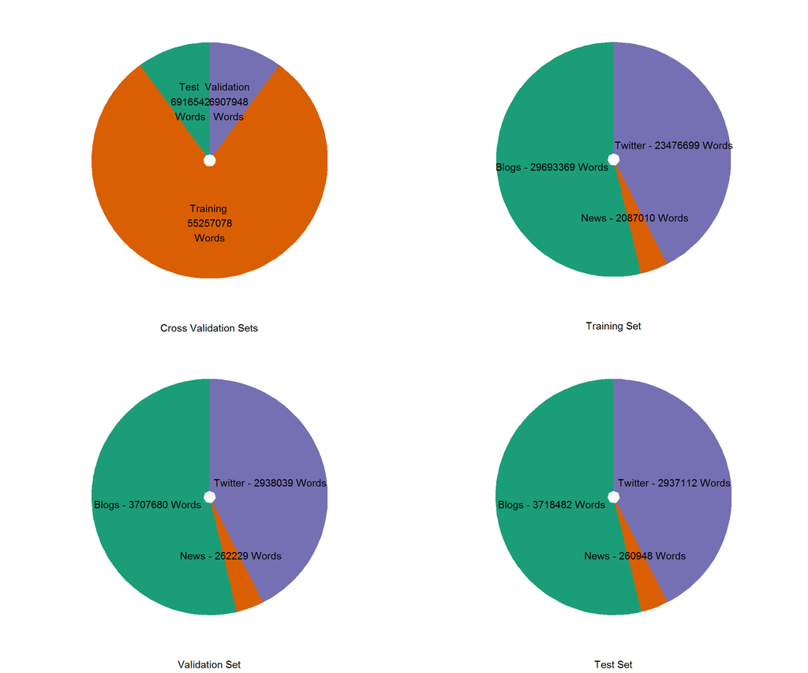

Figure 1: Cross Validation Summary

### Lexical Diversity Analysis

The target lexical size estimate was obtained using Zipf’s law [Zipf1935], and a generalization by Mandelbrot [Mandelbrot1953].

#### Zipf’s Law

Zipf’s Law Popularized by American linguist, George Kingsley Zipf, Zipf’s law explains one of the most basic, yet puzzling aspects of human language: words occur according to a mathematically simple, yet systematic frequency distribution whereby few very high frequency words account for most of the tokens in text. This strikingly simple distribution roughly follows a power law known as Zipf’s law, which states that the frequency of elements with rank $r$:

$$f(r) \propto \frac{1}{r^{\alpha}}$$

(5): Zipf’s Law

where $\alpha \approx 1$ for the classic version of Zipf’s law (Zipf 1935).

Roughly speaking, the frequency by which a word occurs is inversely proportional to its rank such that, given a set of Zipfian distribution frequencies sorted from most to least common, the $nth$ most common frequency will occur with a frequency $1/n$ that of the highest frequency word. So, the second most common word in a natural corpus will occur $1/2$ as much as the most common and the third most common word will occur $1/3$ as often as the most frequent, and so on…roughly speaking.

#### Corpus Word Frequency Distribution (Zipfian Distribution ‘Goodness-of-Fit’)

Insofar as the data approximate a Zipfian distribution, lexical coverage can be ascertained by relating rank to frequencies of ranks. Before estimating coverage of the training set on the test set, the degree to which the word frequency distribution for the entire corpus fit the zipfian distribution was ascertained. The essentially universal way of visualizing the word frequency distribution is to count the number of occurrences of each word in a corpus, then sort each word by its frequency descending where the most frequent word has rank 1, the second most frequent word has rank 2, and so on. Plotting the data on a log-log graph, with the axes being log (rank order) and log (frequency), provides a visual indication of goodness-of-fit. The data conform to Zipf’s law to the extent that the plot is linear. The following plot graphically depicts the empirical and observed log frequencies against log ranks.

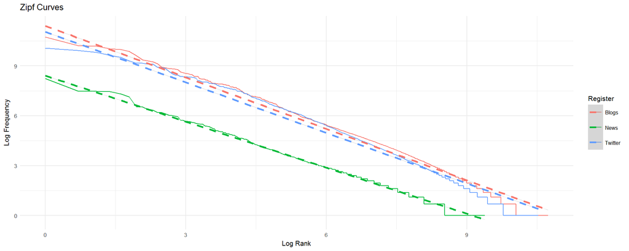

Figure 2: Zipf Plot for Blogs, News and Twitter Registers

Though the data appear to conform *reasonably* well, systematic variation in the residuals reveals a critique of Zipf’s law. The law computes the probability mass over the available data, but doesn’t account for the probability of unseen words in a corpus. Mandelbrot [Mandelbrot61] proposed a generalization that more precisely fits the frequency distribution of language.

$$f(r) \propto \frac{1}{(r+\beta)^{\alpha}}$$
(6): Zipf-Mandelbrot Law

where $\alpha \approx 1$ and $\beta \approx 2.7$ [Mandelbrot61]. By “shifting” $r$ by $\beta$ probability mass is reserved for unseen words. Thus, a Zipf-Mandelbrot model will be used to estimte target vocabulary and lexical size.

#### Lexical Coverage

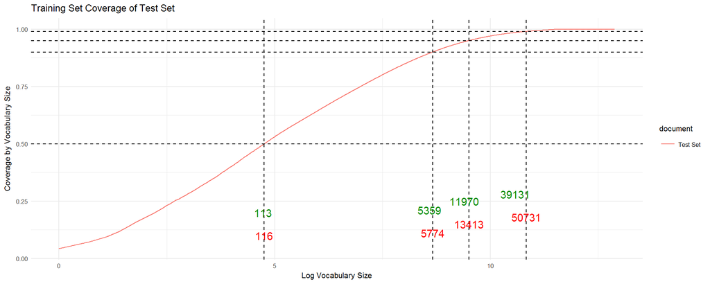

Figure 3: Coverage of Training on Test Set

# Results

# Discussion

# Conclusions

# References

Benoit, Kenneth, and Paul Nulty. 2016. *quanteda: Quantitative Analysis of Textual Data*. https://github.com/kbenoit/quanteda.

Christensen, Hans. 2016. “HC Corpora.” http://www.corpora.heliohost.org/.

Cool-Smileys. 2010. “List of Text Emoticons: The Ultimate Resource.” http://cool-smileys.com/text-emoticons.

Google. 2012. “Offensive Words from Google’s ’What Do You Love’ Project.” https://gist.github.com/jamiew/1112488.

Kennon, Joshua. 2015. “Blog Demographics 2015 Edition: If Life Were a Game, You All Would Be Champions.” http://www.joshuakennon.com/blog-demographics-2015-edition-if-life-were-a-game-you-would-be-champions/.

Kottmann, Jörn, Grant Ingersoll, Isabel Drost, James Kosin, Jason Baldridge, Thomas Morton, William Silva, et al. 2016. “openNLP: Apache OpenNLP Tools Interface.” https://opennlp.apache.org/.

Rstudio Team. 2016. “RStudio – Open source and enterprise-ready professional software for R.” https://www.rstudio.com/.

The R Foundation. 2015. “What is R?” doi:10.1016/B978-0-12-417113-8.09994-X.

Tyler W Rinker. 2016. “qdap: Quantitative Discourse Analysis Package.” [https://trinker.github.io/qdap/ http://github.com/trinker/qdap](https://trinker.github.io/qdap/%20http://github.com/trinker/qdap).

Wikipedia. 2016. “Wikipedia:List of English contractions.” http://www.oxforddictionaries.com/us/definition/english/amn't.

Wiktionary. 2016. “Appendix:English internet slang - Wiktionary.” [https://en.wiktionary.org/wiki/Appendix:English{\_}internet{\_}slang](https://en.wiktionary.org/wiki/Appendix:English%7B/_%7Dinternet%7B/_%7Dslang).

Zipf, George Kingsley. 1935. *The Psycho-Biology Of Language: AN INTRODUCTION TO DYNAMIC PHILOLOGY*. Vol. ix. Houghton Mifflin Company. doi:10.1097/00005053-193701000-00041.

# Appendix

## Appendix A: Hardware / Software Environment

The project was implemented on a Windows x64-based laptop powered by an Intel Core i7-3610QM CPU @ 2.30GHz, 2301 Mhz processor with 4 Cores, 8 Logical Processors, and 16.0 GB of installed memory, running the Microsoft Windows 10 Home operating system, version 10.0.14393 Build 14393. The scripts were authored using the 64 bit version of the R Programming Language, version 3.3.1. (The R Foundation 2015) within R. Studio Version 0.99.903 (Rstudio Team 2016) development environment.

Several **Natural Language Processing (NLP)** software packages provided essential functionality throughout the analysis, modeling, experimentation, and evaluation phases of the project. The quanteda package, version 0.9.9-20 (Benoit and Nulty 2016), provided tokenization, feature selection and analysis functionality. Part-of-speech (POS) tagging was provided by the openNLP package package, version 0.2-6 (Kottmann et al. 2016). Spell checking was performed using the qdap package version 2.2.5 (Tyler W Rinker 2016). Finally, the lsa package version 0.73.1 provided the latent semantic analysis capability [Wild2015].

## Appendix B: Project Dictionary

This section provides the project dictionary used in this project. This contained the file and directory structure, the list of R packages, and constant definitions such as regex patterns used in various places the source code.

## Appendix C: Source Code

Appendix C 1: Get Data

Appendix C 2: Reshape Data

Appendix C 3: Analyze Data

Appendix C 5: Plot Corpus Summary

Appendix C 6: Plot Corpus Audit

Appendix C 4: Clean Data

Appendix C 7: Split Data

Appendix C 8: Analyze Zipf